# Estudio exploratorio y modelado de la serie: Porcentaje de SO2 en el aire

## Contexto

- El azufre atrapado en **combustibles fósiles, industrias metalurgicas, refinerias, termoelectricas o en el magma volcánico** se libera a la atmósfera como gas $SO_2$ tras la combustión o erupción.
- El $SO_2$ impacta negativamente en el sistema respiratorio provocando tos, secreción mucosa, agravamiento del asma y bronquitis crónica; y en el sistema cardiovascular.
- Provoca daño a la vegetación (clorosis) y la corrosión de materiales.

## Sectores de medición de SO2

[interactive chart not shown]

```
[1] "El Camal"    "Carapungo"   "Cotocollao"  "Tumbaco"     "Los Chillos"
[6] "Guamani"
```

Con la frecuencia diaria, pues, el SO2 al ser una sustancia muy volatil, es de interés saber los días que se alcanzan los máximos durante el año. Además que el SO2 suele estar ligado a la actividad humana, entonces, la medición diaria del SO2 tiene la capacidad de mostrar patrones cruciales.

## Diversidad de las series de interés

#### Tendencia

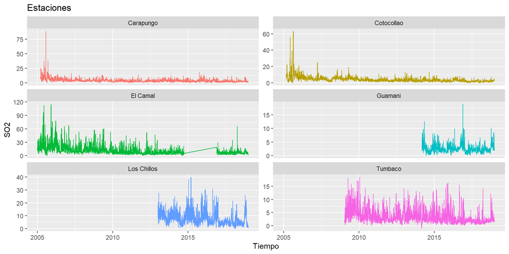

## Test KPSS

Probamos el Test de KPSS para determinar si las series son o no estacionarias:

Resultados de la Prueba KPSS

| Fuente | Estadístico | Valor P |
| --- | --- | --- |
| Carapungo | 11.8131 | 0.0100 |
| Cotocollao | 20.5059 | 0.0100 |
| El Camal | 14.6961 | 0.0100 |
| Guamani | 0.3485 | 0.0994 |
| Los Chillos | 5.0718 | 0.0100 |
| Tumbaco | 9.8193 | 0.0100 |

En todos los casos, se rechaza la idea que las series sean estacionarias pues, el *p-value* es menor o igual a 0.01, a excepción de Guamani, que resulta ser estacionaria.

## Ordenes de diferenciación

Aplicamos el test KPSS para determinar el orden de diferenciación para llevar a las series a ser estacionarias.

**Órdenes de Diferenciación Requeridas (ndiffs)**

| Serie | Orden (d) |
| --- | --- |
| Carapungo | 1 |
| Cotocollao | 1 |
| El Camal | 1 |
| Guamani | 0 |
| Los Chillos | 1 |
| Tumbaco | 1 |

Basta con la diferencia de orden 1 para que las series sean estacionarias

## Orden de diferencia estacional

Aplicamos el test unitroot_nsdiffs para determinar el número de diferencias estacionales requeridas para llevar a las series a ser estacionarias.

**Órdenes de Diferenciación Estacional Requeridas (nsdiffs)**

| Serie | Orden (d) |
| --- | --- |
| Carapungo | 0 |
| Cotocollao | 0 |
| El Camal | 0 |
| Guamani | 0 |
| Los Chillos | 0 |
| Tumbaco | 0 |

Por ende, no es necesario diferenciar estacionalmente la serie. Así, aplicamos la diferenciación de la componente no estacional.

## Series Diferenciadas

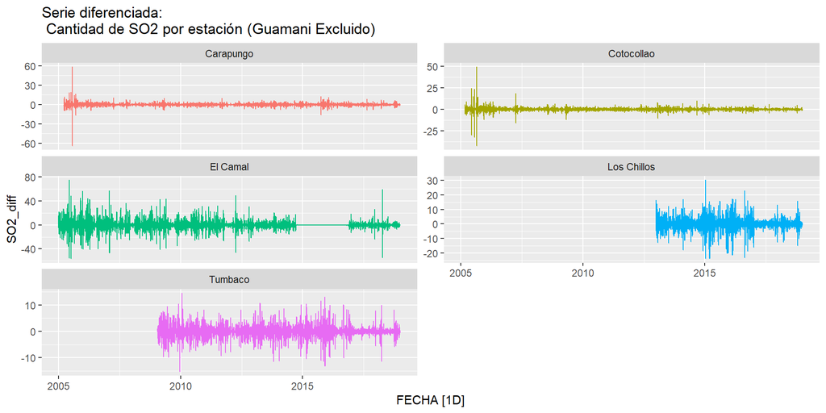

Ahora, con nuestras series transformadas a series estacionarias, la información del ACF y PACF será de interés.

## ACF

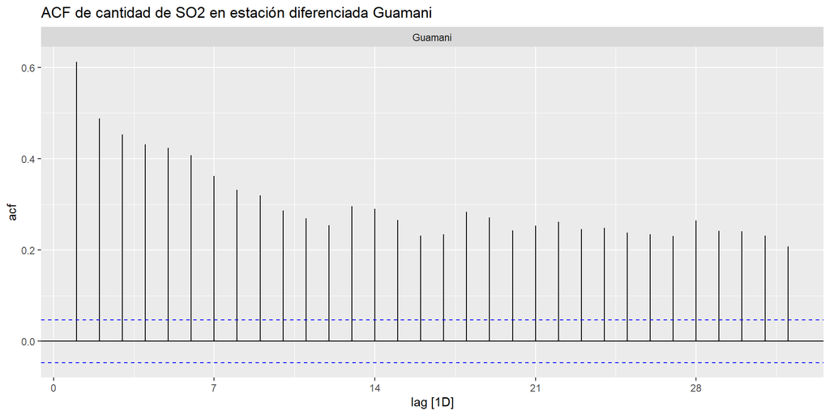

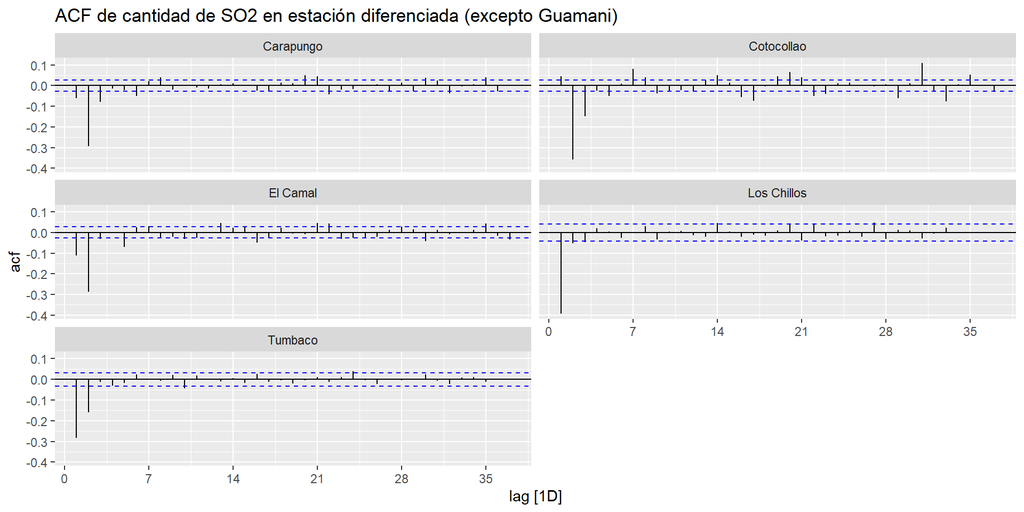

Los gráficos de la ACF, muestran que existe auto-correlación con lags pasados.

## PACF

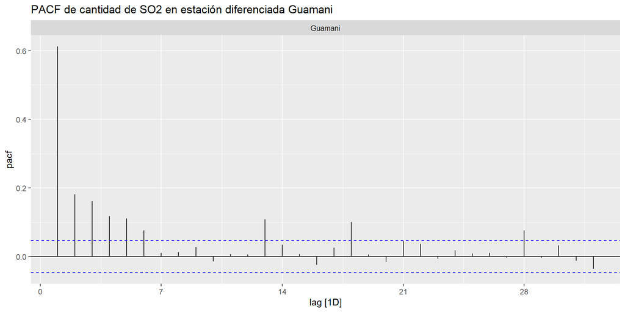

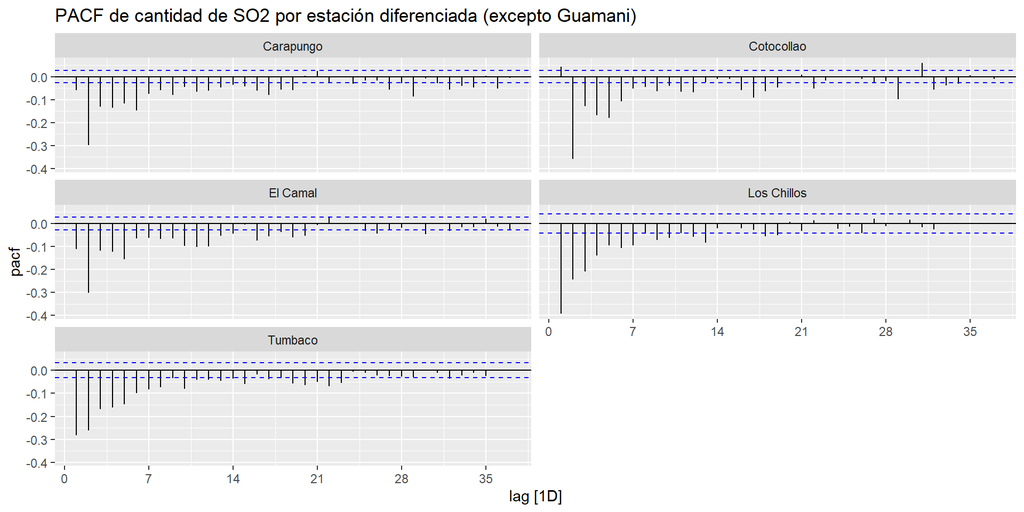

## Modelado

Gracias a los resultados obtenidos, se ha propuesto los siguientes parámetros para el modelamiento:

- **Guamani (Estación estacionaria por defecto)**
  - Diferenciación ($d=0, D=0$)
  - Componente AR ($p=1, P=0$)
  - Componente MA ($q=1, Q=0$)
- **Estaciones no estacionarias.**
  - Diferenciación ($d=1, D=0$)
  - Componente AR ($p=0, P=0$)
  - Componente MA ($q=2, Q=0$)

## Implementación (AIC,BIC, Parsimonia)

Comparación de Ajuste: Modelo Propuesto vs. Automáticos (Lineal, ARIMA automatico)

| ESTACION | MODELO | AIC | AICc | BIC |
| --- | --- | --- | --- | --- |
| Carapungo | Modelo_Lineal | 9491.50 | 9491.54 | 9548.21 |
| Carapungo | Modelo_Automatico | 17964.97 | 17965.00 | 18009.08 |
| Carapungo | Modelo_Propuesto | 18168.02 | 18168.03 | 18186.92 |
| Cotocollao | Modelo_Lineal | 8526.59 | 8526.64 | 8583.33 |
| Cotocollao | Modelo_Automatico | 16698.78 | 16698.81 | 16742.91 |
| Cotocollao | Modelo_Propuesto | 16974.01 | 16974.02 | 16992.93 |
| El Camal | Modelo_Lineal | 18716.48 | 18716.52 | 18773.33 |
| El Camal | Modelo_Automatico | 27553.48 | 27553.50 | 27597.69 |
| El Camal | Modelo_Propuesto | 27702.54 | 27702.54 | 27721.48 |
| Guamani | Modelo_Lineal | 1245.21 | 1245.34 | 1292.46 |
| Guamani | Modelo_Automatico | 4534.81 | 4534.91 | 4576.81 |
| Guamani | Modelo_Propuesto | 4552.95 | 4552.98 | 4573.95 |
| Los Chillos | Modelo_Lineal | 5483.35 | 5483.46 | 5532.57 |
| Los Chillos | Modelo_Automatico | 9672.65 | 9672.67 | 9694.52 |
| Los Chillos | Modelo_Propuesto | 9685.39 | 9685.40 | 9701.79 |
| Tumbaco | Modelo_Lineal | 5397.51 | 5397.57 | 5451.28 |
| Tumbaco | Modelo_Automatico | 12619.20 | 12619.21 | 12637.13 |
| Tumbaco | Modelo_Propuesto | 12663.31 | 12663.32 | 12681.24 |

En rasgos generales, el mejor modelo es el Lineal por tener los valores más bajos de AICm AICc y BIC.

Comparando los modelos: Propuesto y Automático

- Son muy similares según los ajustes de AIC, AICc y BIC
- Ambos modelos tratan de capturar la misma dinámica y convergen a resultados parecidos

Comparación de Modelos por Precisión

| ESTACION | Modelo | RMSE | MAE |
| --- | --- | --- | --- |
| Carapungo | Modelo_Automatico | 2.25 | 1.33 |
| Carapungo | Modelo_Propuesto | 2.31 | 1.36 |
| Carapungo | Modelo_Lineal | 3.24 | 1.96 |
| Carapungo | Modelo_SNAIVE | 4.00 | 2.22 |
| Cotocollao | Modelo_Automatico | 1.91 | 1.10 |
| Cotocollao | Modelo_Propuesto | 1.97 | 1.13 |
| Cotocollao | Modelo_Lineal | 2.86 | 1.67 |
| Cotocollao | Modelo_SNAIVE | 3.47 | 1.83 |
| El Camal | Modelo_Automatico | 7.02 | 4.21 |
| El Camal | Modelo_Propuesto | 7.15 | 4.26 |
| El Camal | Modelo_Lineal | 9.83 | 6.61 |
| El Camal | Modelo_SNAIVE | 12.18 | 7.10 |
| Guamani | Modelo_Automatico | 1.20 | 0.81 |
| Guamani | Modelo_Propuesto | 1.22 | 0.82 |
| Guamani | Modelo_Lineal | 1.55 | 1.11 |
| Guamani | Modelo_SNAIVE | 1.82 | 1.23 |
| Los Chillos | Modelo_Automatico | 3.82 | 2.69 |
| Los Chillos | Modelo_Propuesto | 3.84 | 2.71 |
| Los Chillos | Modelo_Lineal | 4.76 | 3.54 |
| Los Chillos | Modelo_SNAIVE | 5.49 | 3.88 |
| Tumbaco | Modelo_Automatico | 2.12 | 1.50 |
| Tumbaco | Modelo_Propuesto | 2.13 | 1.52 |
| Tumbaco | Modelo_Lineal | 2.52 | 1.89 |
| Tumbaco | Modelo_SNAIVE | 3.19 | 2.26 |

Aunque el lineal tiene el mejor AIC, su predicción es peor que los modelos ARIMA (propuesto y Automático)

Nuestros modelos serán:

Órdenes ARIMA (pdq)(PDQ)

| ESTACION | Tipo_Modelo | Descripcion |
| --- | --- | --- |
| Guamani | Modelo_Propuesto | <ARIMA(1,0,1) w/ mean> |
| Guamani | Modelo_Automatico | <ARIMA(1,0,2)(2,0,1)[7] w/ mean> |
| Carapungo | Modelo_Propuesto | <ARIMA(0,1,2)> |
| Carapungo | Modelo_Automatico | <ARIMA(2,1,2)(2,0,0)[7]> |
| Cotocollao | Modelo_Propuesto | <ARIMA(0,1,2)> |
| Cotocollao | Modelo_Automatico | <ARIMA(1,1,4)(1,0,0)[7]> |
| El Camal | Modelo_Propuesto | <ARIMA(0,1,2)> |
| El Camal | Modelo_Automatico | <ARIMA(3,1,1)(0,0,2)[7]> |
| Los Chillos | Modelo_Propuesto | <ARIMA(0,1,2)> |
| Los Chillos | Modelo_Automatico | <ARIMA(1,1,2)> |
| Tumbaco | Modelo_Propuesto | <ARIMA(0,1,2)> |
| Tumbaco | Modelo_Automatico | <ARIMA(1,1,1)> |

## Significancia y estimaciones

Coeficientes Estimados (MLE) - Solo ARIMA

| ESTACION | .model | term | estimate | std.error | statistic | p.value |
| --- | --- | --- | --- | --- | --- | --- |
| Guamani | Modelo_Propuesto | ar1 | 0.8917434 | 0.0200966 | 44.3728022 | 0.0000000 |
| Guamani | Modelo_Propuesto | ma1 | -0.5269254 | 0.0419551 | -12.5592674 | 0.0000000 |
| Guamani | Modelo_Propuesto | constant | 0.2802359 | 0.0152422 | 18.3855730 | 0.0000000 |
| Guamani | Modelo_Automatico | ar1 | 0.9351115 | 0.0171908 | 54.3959921 | 0.0000000 |
| Guamani | Modelo_Automatico | ma1 | -0.5170234 | 0.0324829 | -15.9168012 | 0.0000000 |
| Guamani | Modelo_Automatico | ma2 | -0.1381674 | 0.0315261 | -4.3826280 | 0.0000126 |
| Guamani | Modelo_Automatico | sar1 | -0.4951397 | 0.3430308 | -1.4434263 | 0.1491229 |
| Guamani | Modelo_Automatico | sar2 | 0.0232801 | 0.0338232 | 0.6882873 | 0.4913852 |
| Guamani | Modelo_Automatico | sma1 | 0.4712320 | 0.3410387 | 1.3817552 | 0.1672661 |
| Guamani | Modelo_Automatico | constant | 0.2474737 | 0.0161369 | 15.3358997 | 0.0000000 |
| Carapungo | Modelo_Propuesto | ma1 | -0.2710336 | 0.0153416 | -17.6665679 | 0.0000000 |
| Carapungo | Modelo_Propuesto | ma2 | -0.5140816 | 0.0170146 | -30.2141512 | 0.0000000 |
| Carapungo | Modelo_Automatico | ar1 | 0.2532484 | 0.0531023 | 4.7690700 | 0.0000019 |
| Carapungo | Modelo_Automatico | ar2 | 0.1247915 | 0.0396036 | 3.1510156 | 0.0016390 |
| Carapungo | Modelo_Automatico | ma1 | -0.4677093 | 0.0493340 | -9.4804574 | 0.0000000 |
| Carapungo | Modelo_Automatico | ma2 | -0.5050740 | 0.0488989 | -10.3289413 | 0.0000000 |
| Carapungo | Modelo_Automatico | sar1 | 0.0309265 | 0.0161820 | 1.9111700 | 0.0560536 |
| Carapungo | Modelo_Automatico | sar2 | 0.0021271 | 0.0161637 | 0.1315982 | 0.8953087 |
| Cotocollao | Modelo_Propuesto | ma1 | -0.1884337 | 0.0140324 | -13.4285090 | 0.0000000 |
| Cotocollao | Modelo_Propuesto | ma2 | -0.5578377 | 0.0143828 | -38.7849471 | 0.0000000 |
| Cotocollao | Modelo_Automatico | ar1 | 0.8807680 | 0.0292830 | 30.0778110 | 0.0000000 |
| Cotocollao | Modelo_Automatico | ma1 | -0.9667881 | 0.0334614 | -28.8926610 | 0.0000000 |
| Cotocollao | Modelo_Automatico | ma2 | -0.4486728 | 0.0213992 | -20.9667775 | 0.0000000 |
| Cotocollao | Modelo_Automatico | ma3 | 0.2423536 | 0.0261272 | 9.2759023 | 0.0000000 |
| Cotocollao | Modelo_Automatico | ma4 | 0.1778331 | 0.0192702 | 9.2284209 | 0.0000000 |
| Cotocollao | Modelo_Automatico | sar1 | 0.0616536 | 0.0164450 | 3.7490679 | 0.0001800 |
| El Camal | Modelo_Propuesto | ma1 | -0.3174779 | 0.0141833 | -22.3839670 | 0.0000000 |
| El Camal | Modelo_Propuesto | ma2 | -0.4775974 | 0.0151311 | -31.5638982 | 0.0000000 |
| El Camal | Modelo_Automatico | ar1 | 0.7159456 | 0.0160226 | 44.6833854 | 0.0000000 |
| El Camal | Modelo_Automatico | ar2 | -0.2143571 | 0.0188958 | -11.3441457 | 0.0000000 |
| El Camal | Modelo_Automatico | ar3 | 0.1528888 | 0.0160164 | 9.5457920 | 0.0000000 |
| El Camal | Modelo_Automatico | ma1 | -0.9889856 | 0.0036318 | -272.3095997 | 0.0000000 |
| El Camal | Modelo_Automatico | sma1 | 0.0259484 | 0.0160346 | 1.6182734 | 0.1056808 |
| El Camal | Modelo_Automatico | sma2 | 0.0313155 | 0.0156619 | 1.9994773 | 0.0456228 |
| Los Chillos | Modelo_Propuesto | ma1 | -0.6833145 | 0.0222385 | -30.7266093 | 0.0000000 |
| Los Chillos | Modelo_Propuesto | ma2 | -0.1801890 | 0.0227470 | -7.9214301 | 0.0000000 |
| Los Chillos | Modelo_Automatico | ar1 | 0.4637172 | 0.1014399 | 4.5713503 | 0.0000052 |
| Los Chillos | Modelo_Automatico | ma1 | -1.1359935 | 0.1093342 | -10.3901060 | 0.0000000 |
| Los Chillos | Modelo_Automatico | ma2 | 0.1967128 | 0.0958160 | 2.0530253 | 0.0402184 |
| Tumbaco | Modelo_Propuesto | ma1 | -0.5370475 | 0.0172933 | -31.0552937 | 0.0000000 |
| Tumbaco | Modelo_Propuesto | ma2 | -0.3279568 | 0.0191597 | -17.1169852 | 0.0000000 |
| Tumbaco | Modelo_Automatico | ar1 | 0.4417737 | 0.0197926 | 22.3201415 | 0.0000000 |
| Tumbaco | Modelo_Automatico | ma1 | -0.9645519 | 0.0077247 | -124.8652527 | 0.0000000 |

## ACF residuos

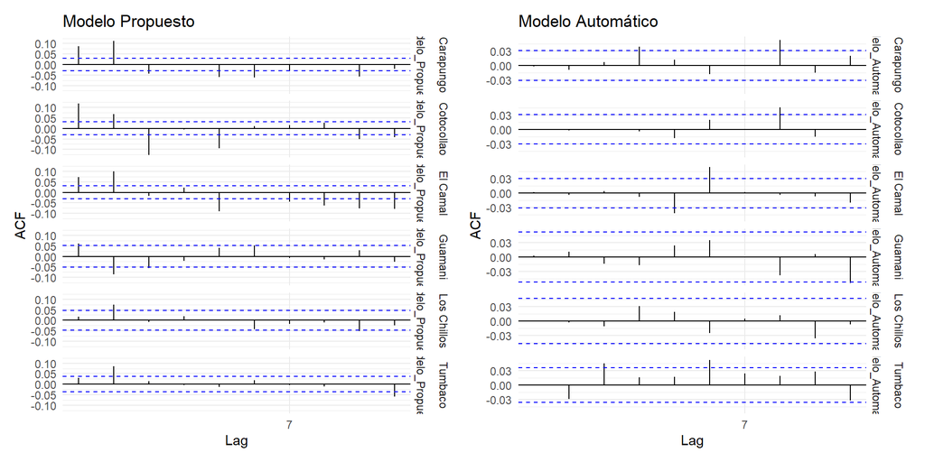

En Cotocollao y Carapungo, notamos que existe una autocorrelación significativa con el rezago 2, lo que podría sugerir la inclusión de un modelo (MA)

## Ljung Box

$H_0$ Residuos Independientes

Comparación de Independencia de Residuos (Ljung-Box)

Comparativa: Modelo Manual vs. Automático

| ESTACION | Modelo Propuesto Q_Manual | Modelo Propuesto P_Manual | Modelo Automático Q_Auto | Modelo Automático P_Auto |
| --- | --- | --- | --- | --- |
| Carapungo | 163.1433 | 0.0000 | 22.7087 | 0.0303 |
| Cotocollao | 219.2591 | 0.0000 | 15.8297 | 0.1992 |
| El Camal | 194.5384 | 0.0000 | 40.4967 | 0.0001 |
| Guamani | 48.0429 | 0.0000 | 21.5957 | 0.0423 |
| Los Chillos | 23.4245 | 0.0243 | 9.7474 | 0.6381 |
| Tumbaco | 48.8752 | 0.0000 | 27.2399 | 0.0071 |

El modelo automático para los Chillos es la que más limpia está, no es afectada por residuos.

## Heterocedasticidad (varianza depende del tiempo)

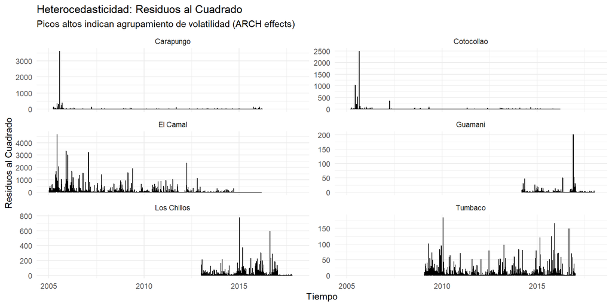

## Estabilidad

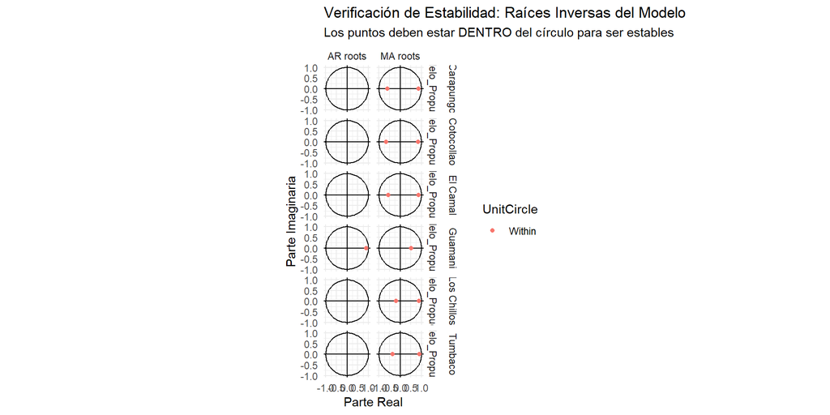

## Pronosticos

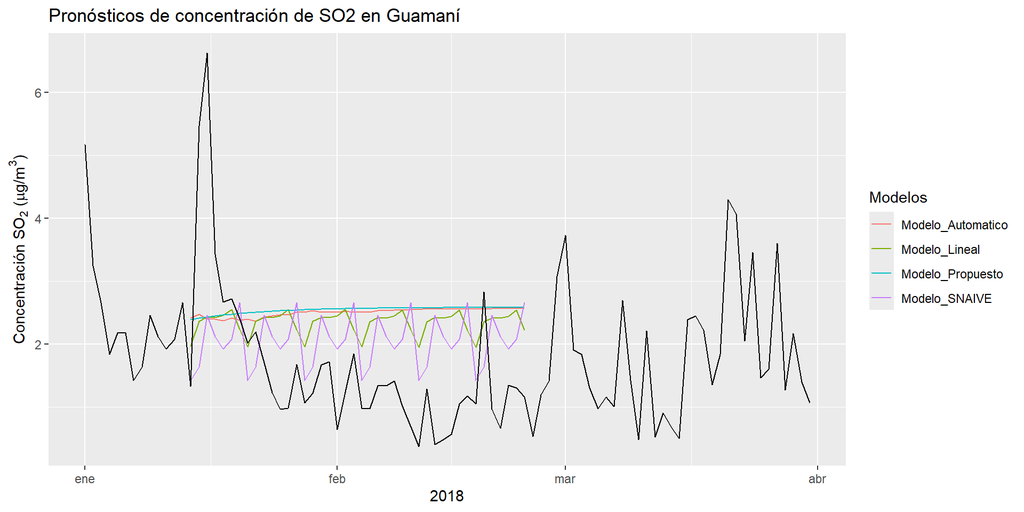

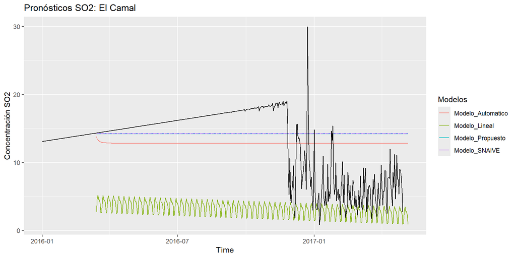

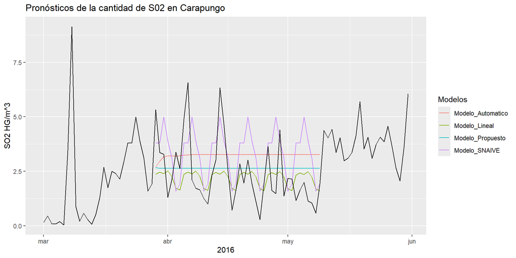

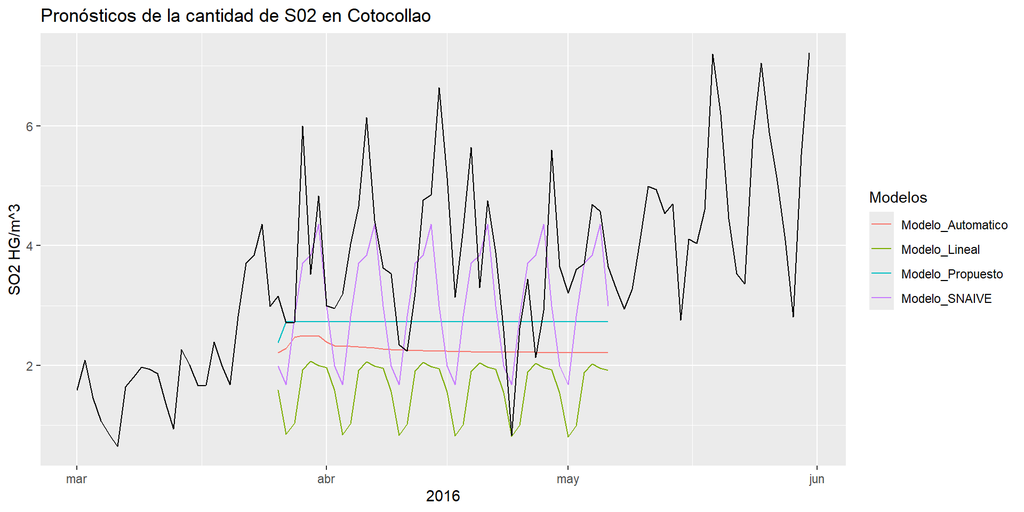

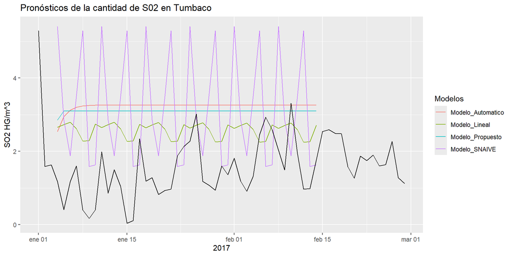

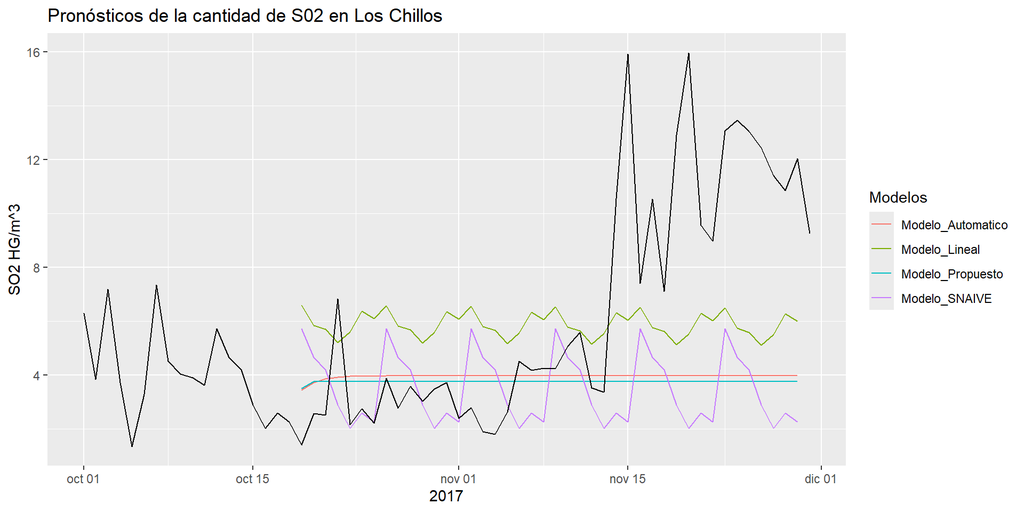

## Mejor modelo

Mejor Modelo por Estación (Criterio: Mínimo RMSE)

| ESTACION | Mejor_Modelo | RMSE | AIC |
| --- | --- | --- | --- |
| Guamani | Modelo_Automatico | 1.20 | 4534.81 |
| Cotocollao | Modelo_Automatico | 1.91 | 16698.78 |
| Tumbaco | Modelo_Automatico | 2.12 | 12619.20 |
| Carapungo | Modelo_Automatico | 2.25 | 17964.97 |
| Los Chillos | Modelo_Automatico | 3.82 | 9672.65 |
| El Camal | Modelo_Automatico | 7.02 | 27553.48 |

## Discusion

Coeficientes de los Modelos Propuestos (ARIMA Manual)

| ESTACION | Termino | Estimacion | Error_Std | P_Valor |
| --- | --- | --- | --- | --- |
| Guamani | ar1 | 0.8917 | 0.0201 | 0 |
| Guamani | ma1 | -0.5269 | 0.0420 | 0 |
| Guamani | constant | 0.2802 | 0.0152 | 0 |
| Carapungo | ma1 | -0.2710 | 0.0153 | 0 |
| Carapungo | ma2 | -0.5141 | 0.0170 | 0 |
| Cotocollao | ma1 | -0.1884 | 0.0140 | 0 |
| Cotocollao | ma2 | -0.5578 | 0.0144 | 0 |
| El Camal | ma1 | -0.3175 | 0.0142 | 0 |
| El Camal | ma2 | -0.4776 | 0.0151 | 0 |
| Los Chillos | ma1 | -0.6833 | 0.0222 | 0 |
| Los Chillos | ma2 | -0.1802 | 0.0227 | 0 |
| Tumbaco | ma1 | -0.5370 | 0.0173 | 0 |
| Tumbaco | ma2 | -0.3280 | 0.0192 | 0 |

##### Componente Autorregresivo (AR): “Memoria”

Se confirma una fuerte dependencia temporal (alta memoria). Físicamente, esto se interpreta como una zona de baja capacidad dispersiva, donde el $SO_2$ se acumula y queda atrapado, probablemente debido a la topografía del sur de Quito o a fuentes de emisión constantes sin ventilación adecuada.

##### Componente de Media Móvil (MA): “Persistencia”

Los coeficientes negativos implican la dispersion de SO2 en las zonas correspondientes, muchas concentraciones de SO2 son desplazadas diariamente a traves de vientos fuertes o por las nubes que las arrastran para generar las lluvias acidas.

El signo negativo en el coeficiente MA indica un mecanismo de corrección rápida. Físicamente, esto sugiere que estas zonas están expuestas a dinámicas de ventilación activa (vientos fuertes o turbulencia) o lavado atmosférico (lluvia). Cuando ocurre un incremento abrupto de SO2 (un choque), este no persiste, sino que es dispersado eficazmente, haciendo que los niveles retornen rápidamente (o incluso caigan por debajo) de la media al día siguiente. El sistema ‘castiga’ los excesos inmediatos.

#### Limitaciones y posibles extenciones

Los modelos ARIMA ignoran variables meteorológicas críticas (viento, lluvia) que limpian o dispersan el contaminante, limitando la predicción de cambios bruscos. Se siguen posibles implementaciones de modelos ARIMAX para incluir forzantes meteorológicos, o modelos híbridos ARIMA para modelar explícitamente la volatilidad variable y mejorar la estimación de riesgo en alertas ambientales.